# Untitled

## 3 uzduotis

# 1.

1. pasileidziame duomenis:

```r
library(dynlm)
data <- M1Germany
```

vertinam tiesine regresija:

```r
mod1 <- lm(logm1~logprice, data=data)
serOrg <- resid(mod1)
```

is liekanu padarome laiko eilute:

```r
eil <- ts(serOrg)
```

3. isbreziame laiko eilute:

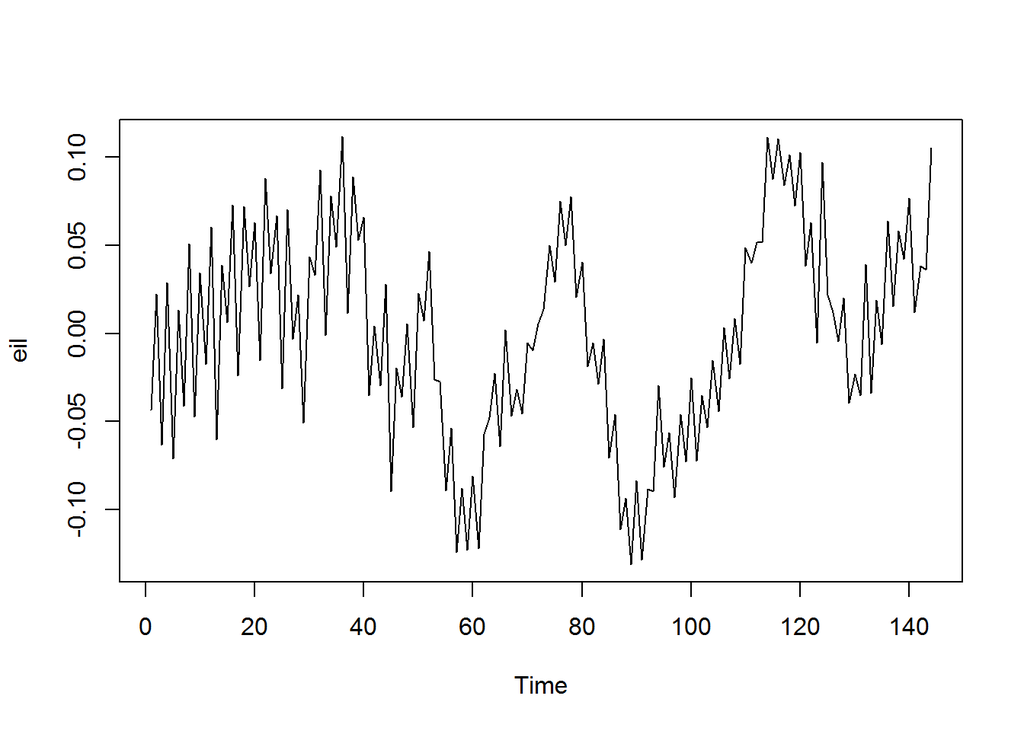

```r
plot(eil)
```

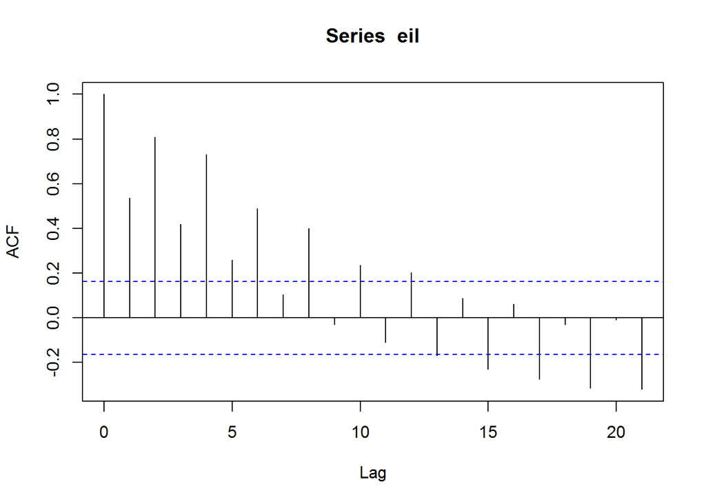

```r
acf(eil)
```

(d)tikriname ar eilute yra stacionari: pirmiausia pasaliname sezoniskuma:

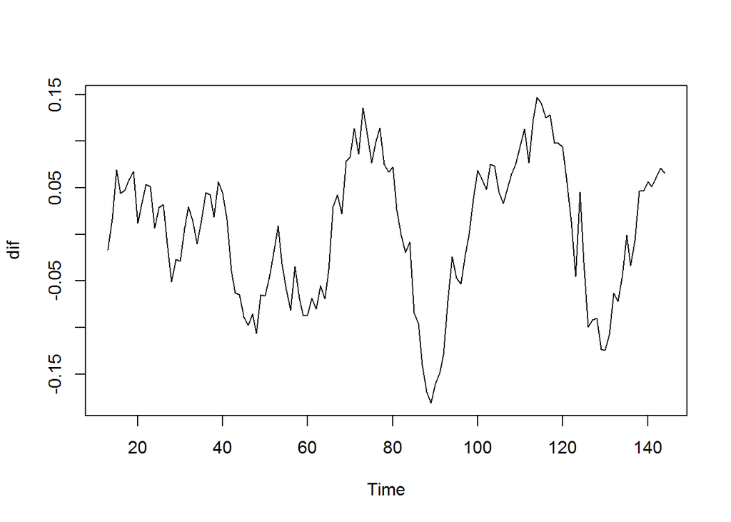

```r
dif <- diff(eil, lag=12)
# uzlaginam per sezona dingsta sezoniskumas
plot(dif)
```

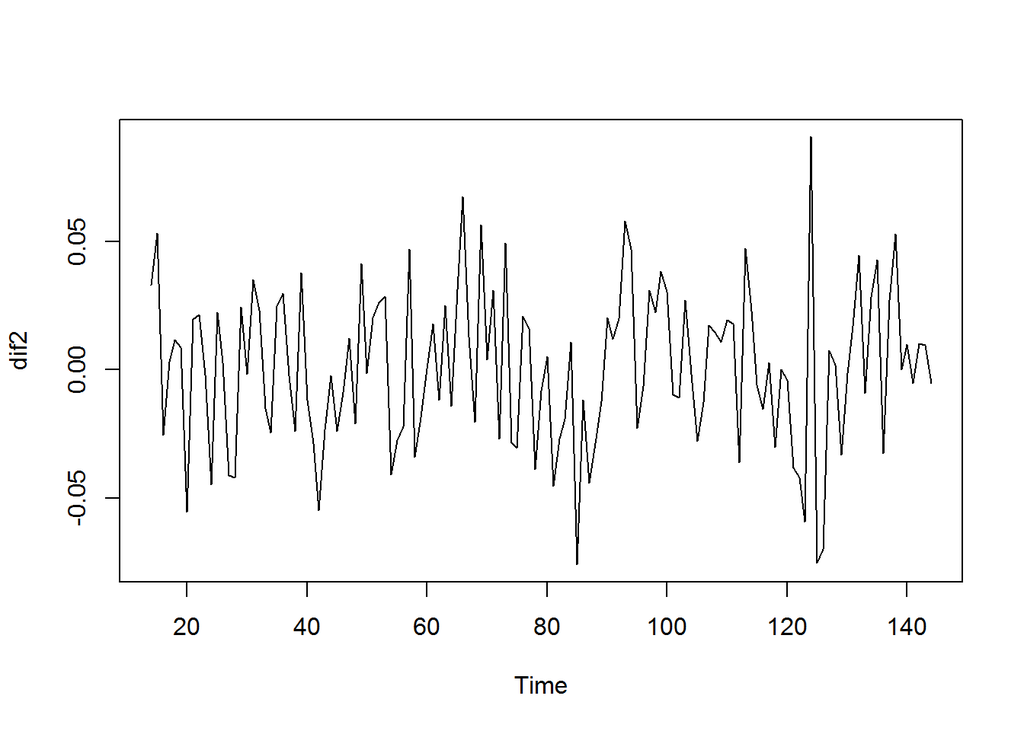

```r
#matome, kad nestacionari dar karta diferencijuojame
dif2 <- diff(dif)
plot(dif2)
```

```r
#jau panasesne i stacionare, pritaikome testa:
library(fpp)
kpss.test(dif2)
```

```
##
##  KPSS Test for Level Stationarity
##
## data:  dif2
## KPSS Level = 0.0513, Truncation lag parameter = 2, p-value = 0.1
```

```r
#kadangi p value daugiau uz 0.05 vadinasi eilute jau stacionari
```

5. Manau, kad eilutei reikalinga box cox transformacija, nes svyravimai nera vienodi ir reguliarus, taigi pritaikysime transformacija:

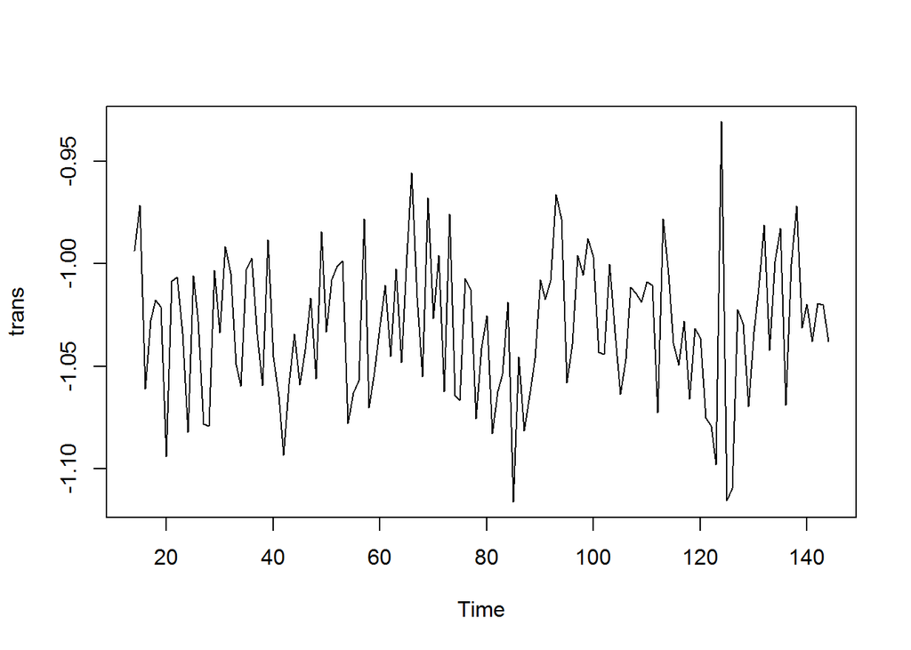

```r
lemda <- BoxCox.lambda(dif2)
trans <- BoxCox(dif2, lambda =lemda)
plot(trans)
```

Taciau, pritaike matome, kad transformacija nepadejo, nes ties viduriu svyravimai truputi didesni taigi sios problemos box cox transformacija neissprendzia taigi vis del to jos taikyti nereikia.

# 2.

1. naudojame ets() funkcija:

```r
mod2 <- ets(dif2)
mod2
```

```
## ETS(A,N,N)
##
## Call:
##  ets(y = dif2)
##
##   Smoothing parameters:
##     alpha = 1e-04
##
##   Initial states:
##     l = 6e-04
##
##   sigma:  0.0308
##
##    AIC   AICc    BIC
## -269.2 -269.1 -263.5
```

ets() siulomas modelis yra ETS(A,N,N) reiskia no seasional,no trend ir additive errors.

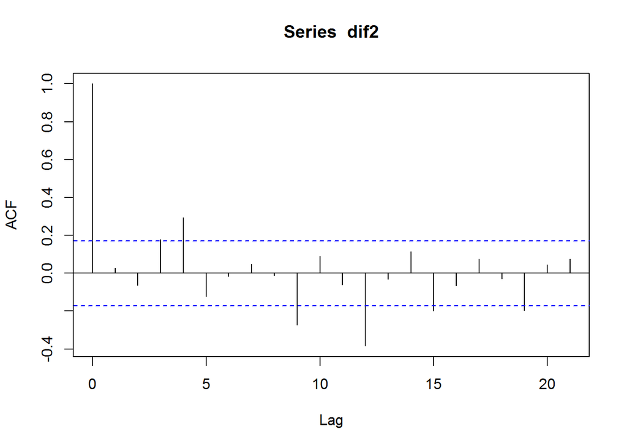

```r
acf(dif2)
```

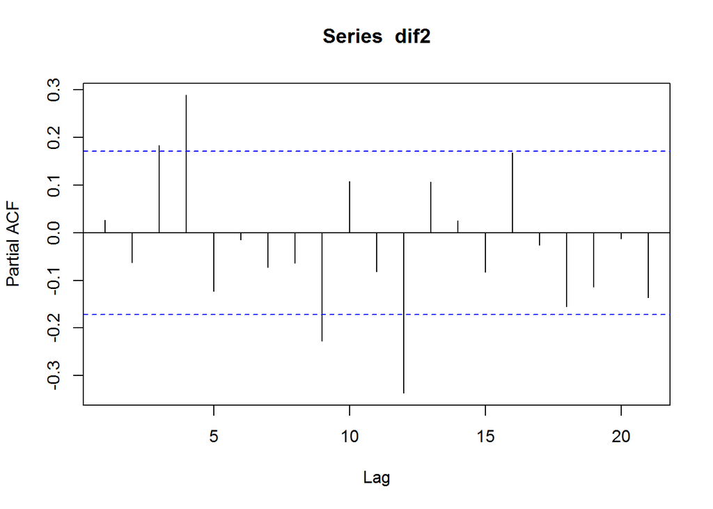

```r
pacf(dif2)
```

matome 4 lagus virs melynos linijos, taigi dalis AR galetu buti 4,o is pacf 3 tai MA dalis galetu buti 3 tai bandome si ARIMA modeli:

```r
mod3 <- Arima(dif2, order=c(4,1,3))
summary(mod3)
```

```
## Series: dif2
## ARIMA(4,1,3)
##
## Coefficients:
##          ar1    ar2   ar3    ar4     ma1     ma2    ma3
##       -0.392  0.055  0.16  0.374  -0.570  -0.517  0.086
## s.e.   0.233  0.220  0.09  0.083   0.252   0.366  0.229
##
## sigma^2 estimated as 0.000825:  log likelihood=274.8
## AIC=-533.6   AICc=-532.4   BIC=-510.6
##
## Training set error measures:
##                     ME    RMSE     MAE    MPE  MAPE   MASE      ACF1
## Training set -0.001215 0.02862 0.02293 -15.38 191.7 0.6928 -0.006486
```

tikrinsime modeliu RMSE :

```r
accuracy(mod2)
```

```
##                     ME    RMSE     MAE   MPE  MAPE   MASE    ACF1
## Training set 6.756e-05 0.03079 0.02499 107.9 114.1 0.7551 0.02652
```

```r
accuracy(mod3)
```

```
##                     ME    RMSE     MAE    MPE  MAPE   MASE      ACF1
## Training set -0.001215 0.02862 0.02293 -15.38 191.7 0.6928 -0.006486
```

Matome, kad mano pasirinkto ARIMA(4.1.3) rmse yra mazesnis vadinasi modelis prognozuos tiksliau, ji renkuosi kaip geriausia.

# 3.

1. tikriname liekanas ar yra baltasis triuksmas:

```r
Box.test(mod2$res, fitdf=0, type="Lj")
```

```
##
##  Box-Ljung test
##
## data:  mod2$res
## X-squared = 0.0943, df = 1, p-value = 0.7588
```

```r
Box.test(mod3$res, fitdf=0, type="Lj")
```

```
##
##  Box-Ljung test
##
## data:  mod3$res
## X-squared = 0.0056, df = 1, p-value = 0.9401
```

matome, kad abieju modeliu liekanos yra baltasis triuksmas nes p value daugiau uz 0.05